# Business Statistics Individual Assessment-York Footfall Dataset

U5666193

2024-10-23

This is to certify that the work I am submitting is my own. All external references and sources are clearly acknowledged and identified within the contents. I am aware of the University of Warwick regulation concerning plagiarism and collusion.

No substantial part(s) of the work submitted here has also been submitted by me in other assessments for accredited courses of study, and I acknowledge that if this has been done an appropriate reduction in the mark I might otherwise have received will be made.

AI was used in the preparation of this work. It was used in the development of the code: It was used to provide example uses of functions or approaches to elements of the challenges which were then interpreted by me and modified to be applicable to this data/report.

# SECTION 1

## Importing libraries

```r
knitr::opts_chunk$set(echo = TRUE, dev= 'png', fig.show = 'hold', fig.width=7, fig.height=5)
library(tidyverse)
library(lubridate)
library(gridExtra)
library(kableExtra)
```

## Data Dictionary

This data comes from cameras that automatically measure the people who walk past a particular location. Here is a summary of the variables within the dataset:

| *Variables* | *Description* |
| --- | --- |
| Date | Date on which the footfall was recorded |
| SiteName | Site where footfall was measured |
| LocationName | Street name in York |
| WeekDay | Week of the day |
| TotalCount | Total number of footfall |
| Recording_ID | Unique ID |

## Read data

Loading data using `read_csv`

```r
york_data <- read_csv('C:\\Users\\Ridhi\\Desktop\\Business stats\\York_Footfall_data.csv')
```

Turning the date column from Character type to Date type.

```r
york_data$Date <- as.Date(york_data$Date, format = "%d-%m-%Y")
```

Checking if the data in SiteName is only for *York*

```r
unique(york_data$SiteName)
```

```
## [1] "York"
```

## Data Quality checks

Checking for missing values

```r
york_data %>%
  summarise_all(~sum(is.na(.)))
```

```
## # A tibble: 1 × 6
##    Date SiteName LocationName WeekDay TotalCount Recording_ID
##   <int>    <int>        <int>   <int>      <int>        <int>
## 1     0        0            0       0         10          100
```

There are 10 missing values in `TotalCount` and 100 missing values in `Recording_ID`

Since Recording_ID is not needed for analysis, no further action will be taken regarding this.

Summary table for each location where footfall was measured:

```r
summary_table <- york_data %>%
    group_by(LocationName) %>%
    summarise(First_date = min(Date, na.rm=TRUE),
    Last_date = max(Date, na.rm=TRUE),
    mean_footfall = mean(TotalCount, na.rm=TRUE),
    sd_footfall = sd(TotalCount, na.rm=TRUE),
    max_footfall = max(TotalCount, na.rm=TRUE),
    min_footfall = min(TotalCount, na.rm=TRUE)
    )
kable(summary_table, caption = "Table 1: Summary of Footfall Statistics") %>%
  kable_styling(bootstrap_options = c("striped", "hover", "condensed"), full_width = F)
```

Table 1: Summary of Footfall Statistics

| LocationName | First_date | Last_date | mean_footfall | sd_footfall | max_footfall | min_footfall |
| --- | --- | --- | --- | --- | --- | --- |
| Church Street | 2015-01-01 | 2017-06-18 | 4352.429 | 1388.959 | 26848 | 402 |
| Coney Street | 2015-01-01 | 2019-12-31 | 23507.291 | 6608.089 | 51050 | 2960 |
| Micklegate | 2015-01-01 | 2019-12-31 | 7486.890 | 4800.012 | 98180 | 1309 |
| Parliament Street | 2015-06-08 | 2019-12-31 | 22631.379 | 6610.363 | 53749 | 1227 |
| Parliament Street at M&S | 2015-01-01 | 2015-06-07 | 22432.234 | 7749.681 | 53057 | 7802 |
| Stonegate | 2015-01-01 | 2019-12-31 | 19901.796 | 17826.401 | 328310 | 1297 |

It was observed that there were two Parliament Streets in the summary table.To ensure they are not duplicates, the `unique` values of the `LocationName` column were printed.

Looking at unique value of `LocationName`

```r
unique(york_data$LocationName)
```

```
## [1] "Church Street"            "Coney Street"
## [3] "Micklegate"               "Parliament Street at M&S"
## [5] "Stonegate"                "Parliament Street"
```

Parliament Street and Parliament Street at M&S are two different values according to this dataset.

Now, the data was filtered to only include variables for the year `2019`.

```r
filtered_york_data <- york_data %>%
                        filter(year(Date)==2019)
filtered_york_data
```

```
## # A tibble: 1,460 × 6
##    Date       SiteName LocationName      WeekDay   TotalCount Recording_ID
##    <date>     <chr>    <chr>             <chr>          <dbl>        <dbl>
##  1 2019-01-01 York     Coney Street      Tuesday        14804       356061
##  2 2019-01-01 York     Micklegate        Tuesday         5888       773736
##  3 2019-01-01 York     Parliament Street Tuesday         8912       746235
##  4 2019-01-01 York     Stonegate         Tuesday        14573       834721
##  5 2019-01-02 York     Coney Street      Wednesday      23069       347503
##  6 2019-01-02 York     Micklegate        Wednesday       6602       867829
##  7 2019-01-02 York     Parliament Street Wednesday      18485       770169
##  8 2019-01-02 York     Stonegate         Wednesday      19570       992992
##  9 2019-01-03 York     Coney Street      Thursday       22876       631403
## 10 2019-01-03 York     Micklegate        Thursday        7092       583649
## # ℹ 1,450 more rows
```

This filtered data would be used for further analysis

But first let’s see if this filtered data has any missing values

```r
filtered_york_data %>%
  summarise_all(~sum(is.na(.)))
```

```
## # A tibble: 1 × 6
##    Date SiteName LocationName WeekDay TotalCount Recording_ID
##   <int>    <int>        <int>   <int>      <int>        <int>
## 1     0        0            0       0          0           23
```

Recoding_ID has 23 unknown values, but it is not needed.

## Including Plots

Distribution of footfall across all days, separated by the locations

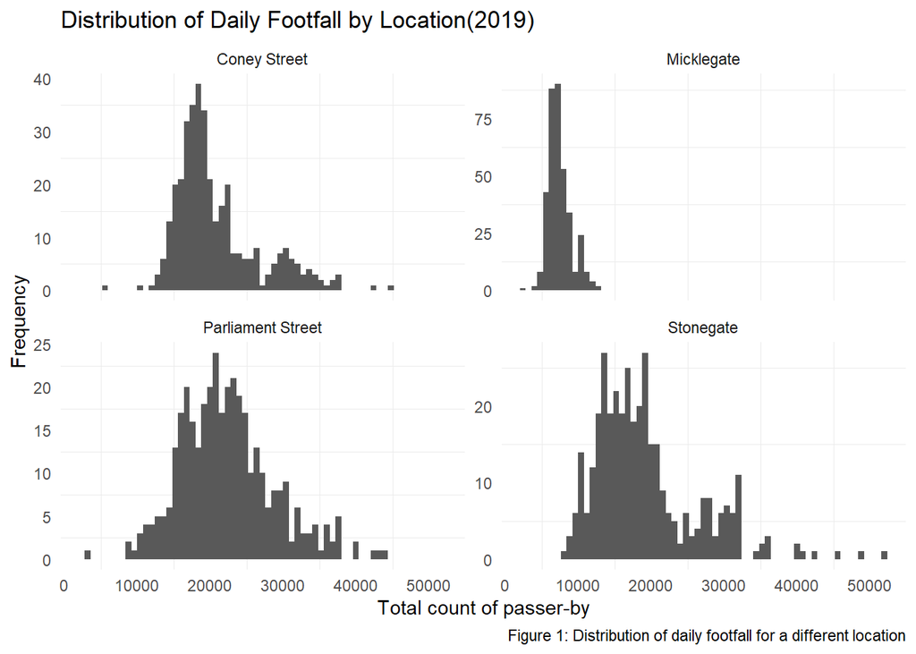

```r
location_distribution <-
  ggplot(filtered_york_data) + geom_histogram(aes(x=TotalCount), binwidth = 800) +
  facet_wrap(~ LocationName, scales = "free_y", drop=FALSE) +
  labs(
    title = "Distribution of Daily Footfall by Location(2019)",
    x = "Total count of passer-by",
    y = "Frequency",
    caption = "Figure 1: Distribution of daily footfall for a different location"
  ) +
  theme_minimal() + theme_minimal() + theme(panel.grid.major = element_blank())
location_distribution
```

Distribution of footfall separated by week days and location

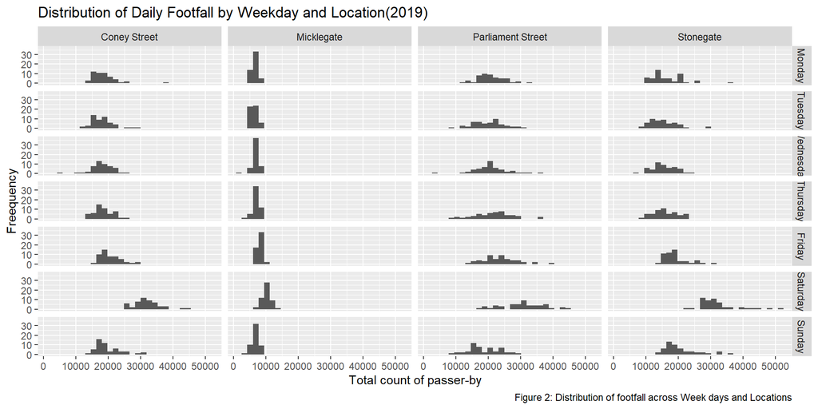

```r
#Ordering of the days of the week to get day wise foot traffic over different locations
filtered_york_data$WeekDay <- factor(filtered_york_data$WeekDay, levels=c("Monday", "Tuesday", "Wednesday", "Thursday", "Friday", "Saturday", "Sunday"))

#plotting day wise footfall
day_location_distribution <-
  ggplot(filtered_york_data) + geom_histogram(aes(x=TotalCount), bins=30,) +     facet_grid(WeekDay ~ LocationName) +
  labs(title = "Distribution of Daily Footfall by Weekday and Location(2019)",   x = "Total count of passer-by" ,
  y = "Freequency",
  caption = "Figure 2: Distribution of footfall across Week days and Locations")
day_location_distribution
```

## Performing $t$-test

$t$-test to compare the footfall on Coney street to Stonegate.

Filtering the data to only include data points of *Coney street and Stonegate*

```r
location_filter <- filtered_york_data %>%
                    filter(LocationName %in% c("Coney Street", "Stonegate"))

location_t_test <- t.test(TotalCount ~ LocationName, data = location_filter)
print(location_t_test)
```

```
##
##  Welch Two Sample t-test
##
## data:  TotalCount by LocationName
## t = 3.3611, df = 699.18, p-value = 0.0008186
## alternative hypothesis: true difference in means between group Coney Street and group Stonegate is not equal to 0
## 95 percent confidence interval:
##   670.9189 2555.7989
## sample estimates:
## mean in group Coney Street    mean in group Stonegate
##                   20817.45                   19204.09
```

The average difference in footfall is 1613.36, which was statistically significant ($t(699.18) = 3.3611$, $p < 0.001$)

$t$-test to compare the footfall on *Coney Street to Stonegate only on weekends*

```r
location_weekend_filter <- filtered_york_data %>%
                    filter(LocationName %in% c("Coney Street", "Stonegate"), WeekDay %in% c("Sunday", "Saturday"))

location_weekend_t_test <- t.test(TotalCount ~ LocationName, data=location_weekend_filter)
print(location_weekend_t_test)
```

```
##
##  Welch Two Sample t-test
##
## data:  TotalCount by LocationName
## t = -0.29072, df = 203.88, p-value = 0.7716
## alternative hypothesis: true difference in means between group Coney Street and group Stonegate is not equal to 0
## 95 percent confidence interval:
##  -2362.601  1755.409
## sample estimates:
## mean in group Coney Street    mean in group Stonegate
##                   25863.37                   26166.96
```

# SECTION 2

### Introduction

This report analyzes pedestrian footfall across four streets in York in the year 2019. The dataset initially had 8,204 observations. After filtering to include only data from the year 2019, only 1,460 observations remained. The objective was to understand the variations in footfall across these streets to identify the best location to place a stall.

### Analysis

We begin with summary of footfall from the year 2015 to 2019 (Table 1)

Table 1: Summary of Footfall Statistics

| LocationName | First_date | Last_date | mean_footfall | sd_footfall | max_footfall | min_footfall |
| --- | --- | --- | --- | --- | --- | --- |
| Church Street | 2015-01-01 | 2017-06-18 | 4352.429 | 1388.959 | 26848 | 402 |
| Coney Street | 2015-01-01 | 2019-12-31 | 23507.291 | 6608.089 | 51050 | 2960 |
| Micklegate | 2015-01-01 | 2019-12-31 | 7486.890 | 4800.012 | 98180 | 1309 |
| Parliament Street | 2015-06-08 | 2019-12-31 | 22631.379 | 6610.363 | 53749 | 1227 |
| Parliament Street at M&S | 2015-01-01 | 2015-06-07 | 22432.234 | 7749.681 | 53057 | 7802 |
| Stonegate | 2015-01-01 | 2019-12-31 | 19901.796 | 17826.401 | 328310 | 1297 |

The distribution of footfall across all days in 2019 is shown in Figure 1.

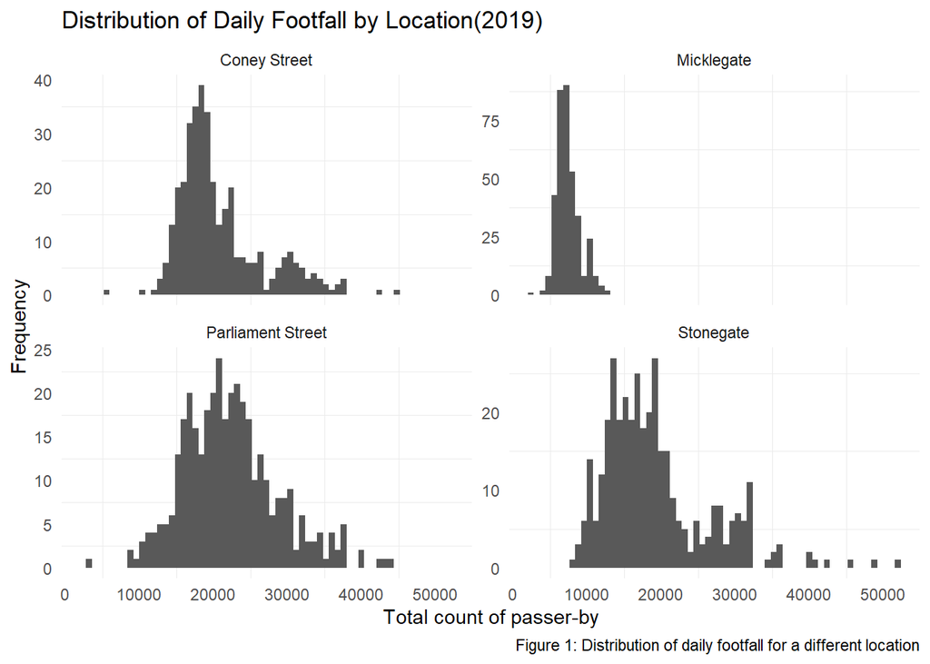

This figure shows some interesting facts about the foot traffic.

Coney street had a rare occurrence where around 45k people walked about that street. Stonegate on the other hand had a few more instances where foot traffic reached about 50k.

Another interesting thing I noticed is that in 2019, footfall was measured only for 4 streets including Coney Street, Micklegate, Parliament Street and Stonegate.

Figure 2 shows a deeper understanding about the busy and quiet days.

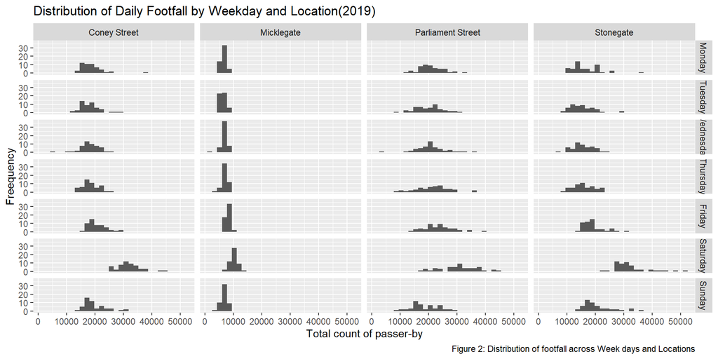

A $t$-test analysis shows that Coney street’s mean footfall of 20817.45 is significantly higher than Stonegate’s mean footfall of 19204.09, $t(699.18) = 3.3611$, $p < 0.001$.

Therefore, we have come to the decision that weekdays are the best days to place a stall on *Coney street* because it sees more foot traffic on a daily basis then Stonegate. It will help the stall to get more exposure.

For weekends, *both Coney street and Stonegate* have potential because they see similar foot traffic. I would only advise the promoter to place their stall on weekends if they have considered additional factors like ease of setup, rental costs or specific target audiences.